# Decision Trees and Random Forests in Python

## Prediction and Evaluation

Let's evaluate our decision tree.

```python
dtree = pickle.load(open(filename,'rb'))
dtree
```

```
DecisionTreeClassifier(max_depth=5, min_samples_leaf=10, min_samples_split=8)
```

```python
predictions = dtree.predict(X_test)
```

```python
from sklearn.metrics import classification_report,confusion_matrix
```

```python
print(classification_report(y_test,predictions,digits=4))
```

```
              precision    recall  f1-score   support

      absent     0.9474    0.9000    0.9231        20
     present     0.6667    0.8000    0.7273         5

    accuracy                         0.8800        25
   macro avg     0.8070    0.8500    0.8252        25
weighted avg     0.8912    0.8800    0.8839        25
```

```python
con_mat = confusion_matrix(y_test,predictions,labels=['absent','present'])
print(con_mat)
```

```
[[18  2]
 [ 1  4]]
```

```python
# F1
precision = con_mat[1][1]/(con_mat[0][1] + con_mat[1][1])
recall = con_mat[1][1] / (con_mat[1][0] + con_mat[1][1])
f1 = 2*precision*recall/(precision+recall)
print(f1)
```

```
0.7272727272727272
```

## Tree Visualization

Scikit learn actually has some built-in visualization capabilities for decision trees, you won't use this often and it requires you to install the pydot library, but here is an example of what it looks like and the code to execute this:

[output not shown]

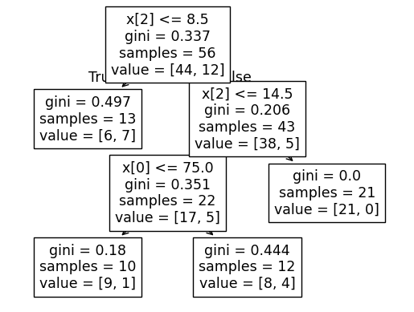

```python
from sklearn import tree
tree.plot_tree(dtree)
```

```python
print(X.columns) # feature names
print(y.unique().tolist()) # class names
```

```
Index(['Age', 'Number', 'Start'], dtype='object')
['absent', 'present']
```

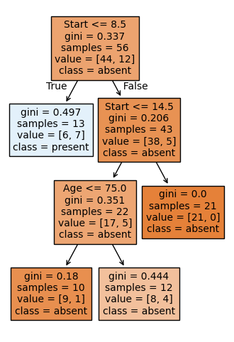

```python
fn=X.columns # feature names
cn=y.unique().tolist() # class names
fig, axes = plt.subplots(nrows = 1,ncols = 1,figsize = (4,6), dpi=100)
tree.plot_tree(dtree,
               feature_names = fn,
               class_names=cn,
               filled = True);
fig.savefig('imagename.png')
```

## Random Forest

```python
from sklearn.ensemble import RandomForestClassifier

forest = RandomForestClassifier(
    n_estimators=100,
    criterion="gini",
    bootstrap=False,
    max_depth=5,
    max_features="sqrt",
    class_weight="balanced",
    random_state=42,
    ccp_alpha=0.001,
)
```

```python
forest.fit(X_train,y_train)
```

```
RandomForestClassifier(bootstrap=False, ccp_alpha=0.001,
                       class_weight='balanced', max_depth=5, random_state=42)
```

```python
pred = forest.predict(X_test)
```

```python
conf = confusion_matrix(y_test, pred, labels=["absent", "present"])
prec = conf[1][1]/(conf[1][1] + conf[0][1])
rec = conf[1][1]/(conf[1][1] + conf[1][0])
f1 = 2*prec*rec/(prec+rec)
print(f1)
```

```
0.5882352941176471
```

### Cross Validation

```python
from sklearn.model_selection import cross_val_score
```

```python
score = cross_val_score(forest, X_test, y_test, cv=5, scoring='f1_macro')

print(f"Average F1: {score.mean():.2f}")
print(f"Stability: {score.std():.2f}")
```

```
Average F1: 0.73
Stability: 0.25
```

# Summary

With the Single Decision Tree the F1 from the prediction is 0.72, and from the Random Forest the Average F1 is 0.73 with 0.25 Stability

## Parameters

In Decision Tree I use `min_samples_leaf=10, criterion='gini', max_depth=5, min_samples_split=8` I've change the split criterion to gini with max tree depth of 5 and minimum sample split of 8

for Random Forest I use `n_estimators=100, criterion="gini", bootstrap=False, max_depth=5, max_features="sqrt", class_weight="balanced", random_state=42, ccp_alpha=0.001` I use balanced class weight since our class of data is mostly 'absent' and bootstrap is set to False to allow every tree to see all the data since our data is very small (80 records) and set max feature to be sqrt of total feature this make each tree not identical to each other